# 2016_summer_data_report

Xiulin Gao

11/24/2016

# Main questions

## 1. Are there species variations in selected flammability measurements?

According to my interest on ecological effect of grass species may have on woody species, selected flammability measurements include: time duration when sensored temperatue is above 60 celsius degree (seperated into <10cm and >10cm sections); total degree of temperature(>60) had been geenrated during a burn (<10cm and >10cm); biomass loss rate at flaming and smoldering stage seperately(for whole plant, but for different burn stage) and maximum flame height(for whole plant).

## 2. Does total above ground biomass influence flammability measurements? And how?

## 3. Does biomass density at affect measured flammability at >10cm and <10cm section?

This question will be answered for >10cm and <10cm plant section seperately, because I want to exam if biomass allocation will influence measured flammability at two sections. And the biological implication is heat produced at <10cm has more effect on reproductive organs of grass, however, heat produced at >10cm has more effect on neighbors, such as woody species.

# Code and Results

First of all, obtain all the datsets

## 1.species variation in interested flammability measurements

### 1) species variation in duration

A. >10cm section

```r
durFullMod <- lm( dur ~ logtmass*sp.cd + density*sp.cd, data = temp.abovesec)
durSpNull <- lm( dur ~ logtmass + density, data = temp.abovesec)
anova(durFullMod, durSpNull)
```

```
## Analysis of Variance Table
##
## Model 1: dur ~ logtmass * sp.cd + density * sp.cd
## Model 2: dur ~ logtmass + density
##   Res.Df     RSS  Df Sum of Sq      F Pr(>F)
## 1     85 5827948
## 2    106 7229077 -21  -1401129 0.9731 0.5035
```

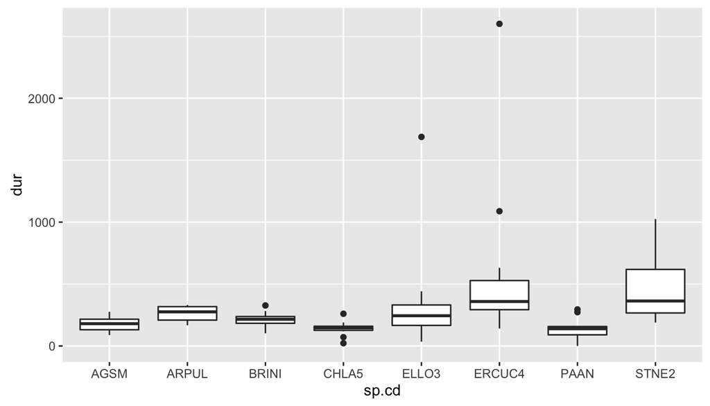

B. <10cm section

```r
dur10FullMod <- lm(dur ~ logtmass*sp.cd + density10*sp.cd, data = temp.belowsec)
dur10SpNull <- lm(dur ~ logtmass + density10, data = temp.belowsec)
anova(dur10FullMod, dur10SpNull)
```

```
## Analysis of Variance Table
##
## Model 1: dur ~ logtmass * sp.cd + density10 * sp.cd
## Model 2: dur ~ logtmass + density10
##   Res.Df     RSS  Df Sum of Sq      F Pr(>F)
## 1     85 6438256
## 2    106 9486976 -21  -3048721 1.9167 0.0195 *
## ---
## Signif. codes:  0 '***' 0.001 '**' 0.01 '*' 0.05 '.' 0.1 ' ' 1
```

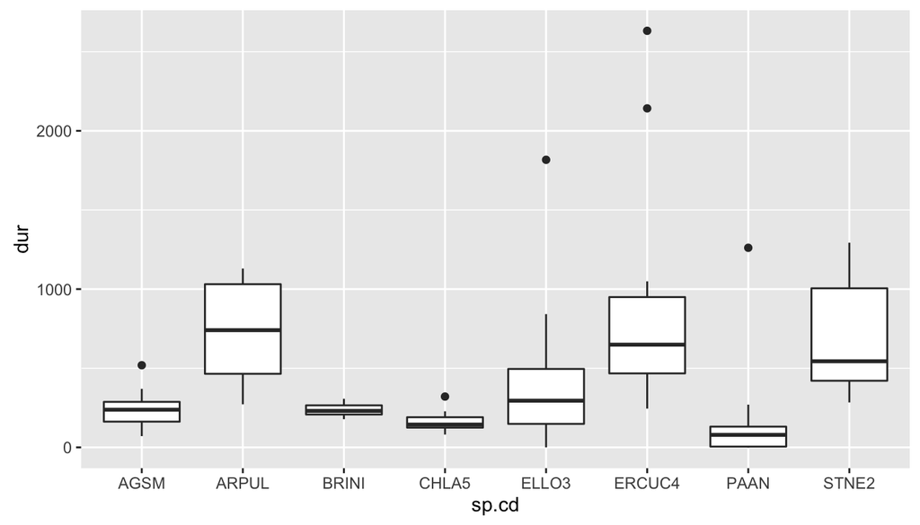

**Conclusion** there is species variation in duration at <10cm section

### 2)species variation in total degree of temperature(>60)

A. >10cm

```r
degFullMod <- lm(degsec ~ logtmass*sp.cd + density*sp.cd,data = temp.abovesec)
degSpNull <- lm(degsec ~ logtmass + density, data = temp.abovesec)
anova(degFullMod, degSpNull)
```

```
## Analysis of Variance Table
##
## Model 1: degsec ~ logtmass * sp.cd + density * sp.cd
## Model 2: degsec ~ logtmass + density
##   Res.Df        RSS  Df   Sum of Sq      F  Pr(>F)
## 1     85 5.6001e+10
## 2    106 7.9829e+10 -21 -2.3828e+10 1.7222 0.04264 *
## ---
## Signif. codes:  0 '***' 0.001 '**' 0.01 '*' 0.05 '.' 0.1 ' ' 1
```

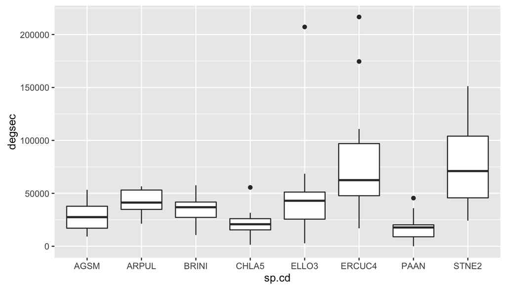

B. <10cm

```r
deg10FullMod <- lm(degsec ~ logtmass*sp.cd + density10*sp.cd, data = temp.belowsec)
deg10SpNull <- lm(degsec ~ logtmass + density10, data= temp.belowsec)
anova(deg10FullMod, deg10SpNull)
```

```
## Analysis of Variance Table
##
## Model 1: degsec ~ logtmass * sp.cd + density10 * sp.cd
## Model 2: degsec ~ logtmass + density10
##   Res.Df        RSS  Df   Sum of Sq      F   Pr(>F)
## 1     85 1.1828e+11
## 2    106 1.9371e+11 -21 -7.5432e+10 2.5813 0.001155 **
## ---
## Signif. codes:  0 '***' 0.001 '**' 0.01 '*' 0.05 '.' 0.1 ' ' 1
```

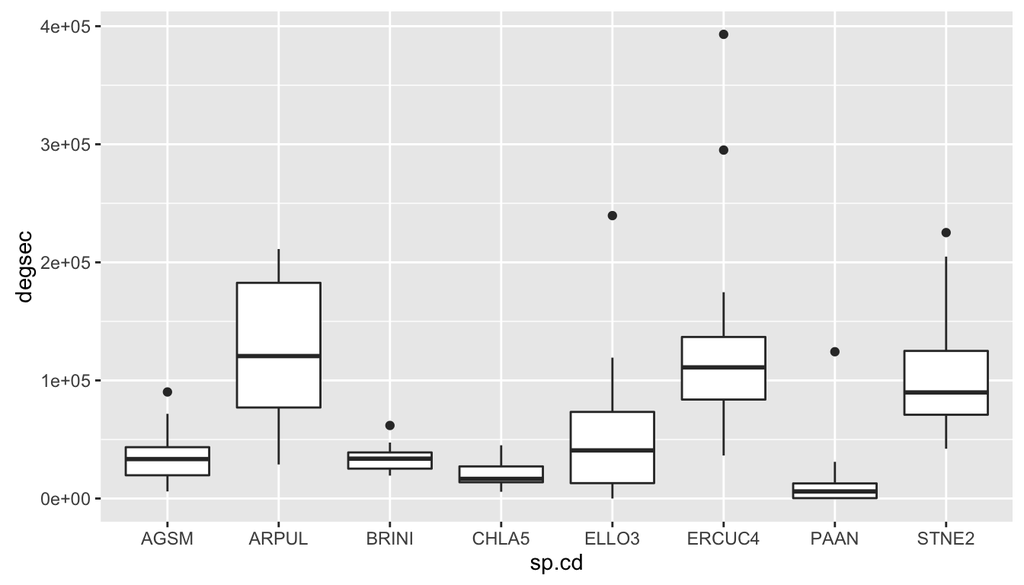

**Conclusion** There is species variation in total degree of temperature(>60) produced at both >10cm and <10cm sections.

### 3)species variation in maximum flame height

```r
flamhFullMod <- lm(max.fh ~ logtmass*sp.cd + density10*sp.cd +
                     density*sp.cd + height*sp.cd, data=flam.height)
flamhSpNull <- lm(max.fh ~ logtmass + density10 + density + height, data=flam.height)
anova(flamhFullMod, flamhSpNull)
```

```
## Analysis of Variance Table
##
## Model 1: max.fh ~ logtmass * sp.cd + density10 * sp.cd + density * sp.cd +
##     height * sp.cd
## Model 2: max.fh ~ logtmass + density10 + density + height
##   Res.Df   RSS  Df Sum of Sq     F Pr(>F)
## 1     84 33190
## 2    119 49315 -35    -16125 1.166 0.2803
```

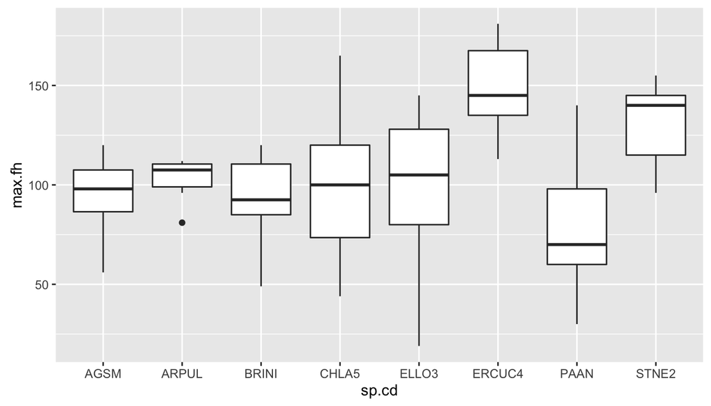

**Conclusion** There is no species variation in maximum flame height.

### 4)species variation in biomass loss rate

A. Flaming stage

```r
flossFullMod <- lm(lossrate ~ logtmass*sp.cd + density10*sp.cd +
                     density*sp.cd, data = flam.loss)
flossSpNull <- lm(lossrate ~ logtmass + density + density10, data = flam.loss)
anova(flossFullMod, flossSpNull)
```

```
## Analysis of Variance Table
##
## Model 1: lossrate ~ logtmass * sp.cd + density10 * sp.cd + density * sp.cd
## Model 2: lossrate ~ logtmass + density + density10
##   Res.Df     RSS  Df Sum of Sq      F  Pr(>F)
## 1     63  8.4832
## 2     91 17.3078 -28   -8.8246 2.3406 0.00268 **
## ---
## Signif. codes:  0 '***' 0.001 '**' 0.01 '*' 0.05 '.' 0.1 ' ' 1
```

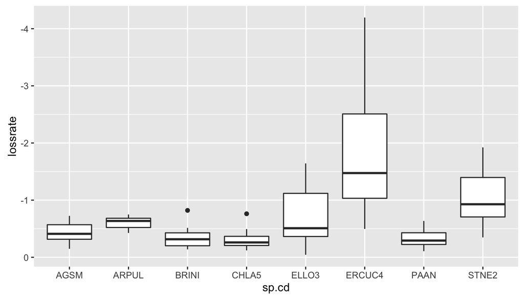

B. Smoldering stage

```r
slossFullMod <- lm(lossrate ~ logtmass*sp.cd + density10*sp.cd +
                     density*sp.cd, data = smog.loss)
slossSpNull <- lm(lossrate ~ logtmass + density10 + density, data = smog.loss)
anova(slossFullMod, slossSpNull)
```

```
## Analysis of Variance Table
##
## Model 1: lossrate ~ logtmass * sp.cd + density10 * sp.cd + density * sp.cd
## Model 2: lossrate ~ logtmass + density10 + density
##   Res.Df     RSS  Df Sum of Sq     F Pr(>F)
## 1     55 0.87488
## 2     83 1.49619 -28  -0.62131 1.395 0.1447
```

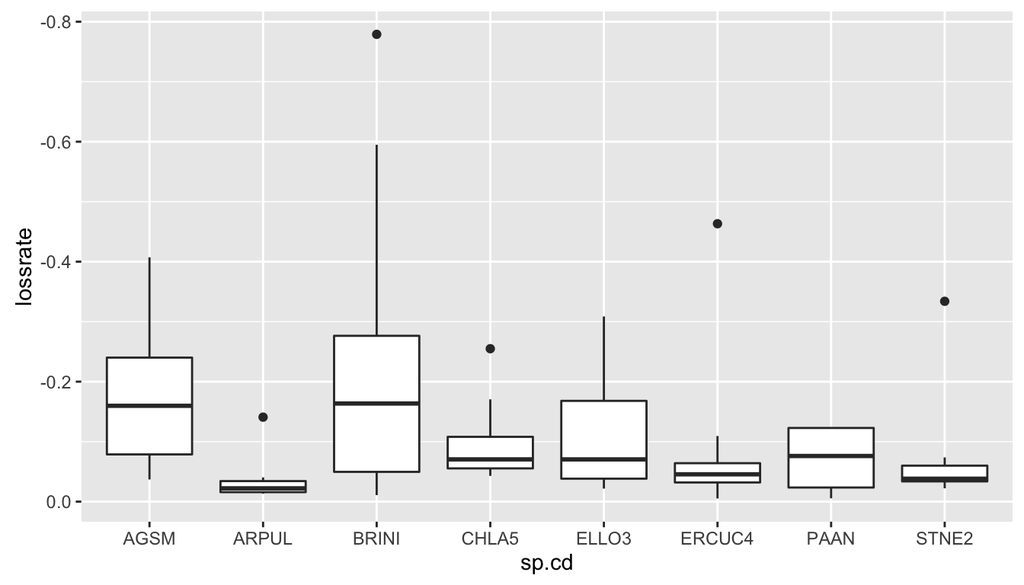

**Conclusion** There is variation in biomass loss rate only at flaming stage but not at smoldering stage.

## 2.Does total biomass affect interested flammability measurements?

### 1) biomass effect on duration

A.>10cm

```r
durFullMod <- lm( dur ~ logtmass*sp.cd + density*sp.cd, data = temp.abovesec)
durMaNull <- lm(dur ~ density*sp.cd, data = temp.abovesec)
anova(durFullMod, durMaNull)
```

```
## Analysis of Variance Table
##
## Model 1: dur ~ logtmass * sp.cd + density * sp.cd
## Model 2: dur ~ density * sp.cd
##   Res.Df     RSS Df Sum of Sq      F    Pr(>F)
## 1     85 5827948
## 2     93 8209737 -8  -2381788 4.3423 0.0002017 ***
## ---
## Signif. codes:  0 '***' 0.001 '**' 0.01 '*' 0.05 '.' 0.1 ' ' 1
```

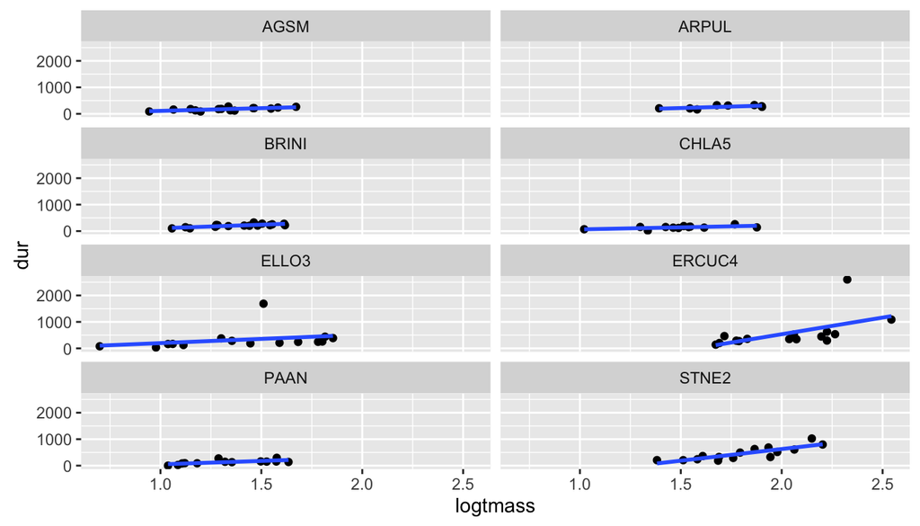

B. <10cm

```r
dur10FullMod <- lm( dur ~ logtmass*sp.cd + density10*sp.cd, data = temp.belowsec)
dur10MaNull <- lm(dur ~ density10*sp.cd, data = temp.belowsec)
anova(dur10FullMod, dur10MaNull)
```

```
## Analysis of Variance Table
##
## Model 1: dur ~ logtmass * sp.cd + density10 * sp.cd
## Model 2: dur ~ density10 * sp.cd
##   Res.Df      RSS Df Sum of Sq      F    Pr(>F)
## 1     85  6438256
## 2     93 11277960 -8  -4839705 7.9869 5.724e-08 ***
## ---
## Signif. codes:  0 '***' 0.001 '**' 0.01 '*' 0.05 '.' 0.1 ' ' 1
```

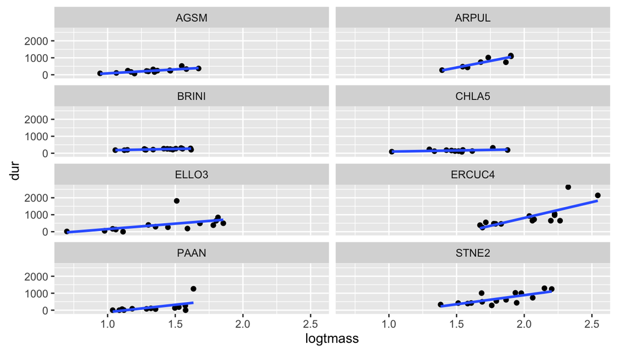

**Conclusion** There is significant effect of total biomass on duration, positive.

### 2)biomass effect on total degree of temperature(>60)

A. >10cm

```r
degFullMod <- lm(degsec ~ logtmass*sp.cd + density*sp.cd, data = temp.abovesec)
degMaNull <- lm(degsec ~ density*sp.cd, data = temp.abovesec)
anova(degFullMod, degMaNull)
```

```
## Analysis of Variance Table
##
## Model 1: degsec ~ logtmass * sp.cd + density * sp.cd
## Model 2: degsec ~ density * sp.cd
##   Res.Df        RSS Df   Sum of Sq      F    Pr(>F)
## 1     85 5.6001e+10
## 2     93 9.6942e+10 -8 -4.0942e+10 7.7678 9.049e-08 ***
## ---
## Signif. codes:  0 '***' 0.001 '**' 0.01 '*' 0.05 '.' 0.1 ' ' 1
```

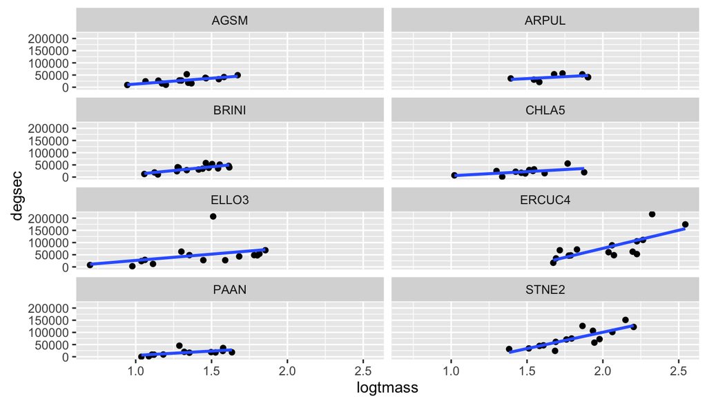

B.<10cm

```r
deg10FullMod <- lm(degsec ~ logtmass*sp.cd + density10*sp.cd,data = temp.belowsec)
deg10MaNull <- lm(degsec ~ density10*sp.cd, data = temp.belowsec)
anova(deg10FullMod, deg10MaNull)
```

```
## Analysis of Variance Table
##
## Model 1: degsec ~ logtmass * sp.cd + density10 * sp.cd
## Model 2: degsec ~ density10 * sp.cd
##   Res.Df        RSS Df   Sum of Sq     F    Pr(>F)
## 1     85 1.1828e+11
## 2     93 2.4063e+11 -8 -1.2235e+11 10.99 1.608e-10 ***
## ---
## Signif. codes:  0 '***' 0.001 '**' 0.01 '*' 0.05 '.' 0.1 ' ' 1
```

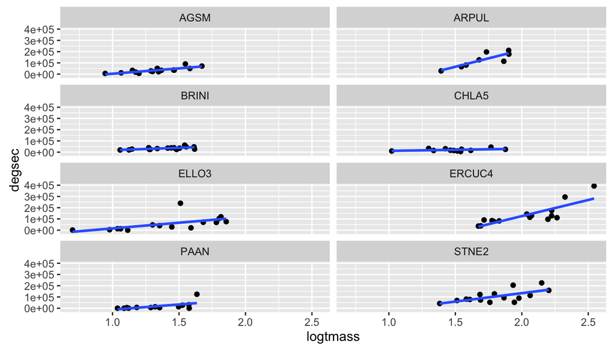

**Conclusion** There is significant biomass effect on total degree of temperature(>60) produced, positive.

### 3)biomass effect on maximum flame height

```r
flamhFullMod <- lm(max.fh ~ logtmass*sp.cd + density10*sp.cd +
                  density*sp.cd + height*sp.cd, data = flam.height)
flamhMaNull <- lm(max.fh ~ density10*sp.cd + density*sp.cd +
                    height*sp.cd, data = flam.height)
anova(flamhFullMod, flamhMaNull)
```

```
## Analysis of Variance Table
##
## Model 1: max.fh ~ logtmass * sp.cd + density10 * sp.cd + density * sp.cd +
##     height * sp.cd
## Model 2: max.fh ~ density10 * sp.cd + density * sp.cd + height * sp.cd
##   Res.Df   RSS Df Sum of Sq      F    Pr(>F)
## 1     84 33190
## 2     92 51964 -8    -18774 5.9395 5.043e-06 ***
## ---
## Signif. codes:  0 '***' 0.001 '**' 0.01 '*' 0.05 '.' 0.1 ' ' 1
```

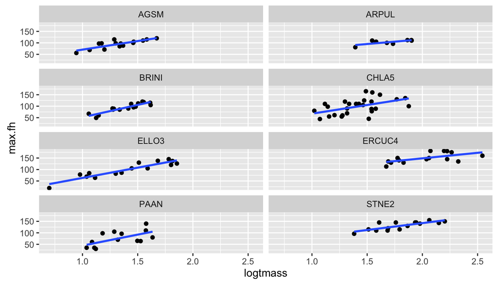

**Conclusion** There is significant biomass influence on maximum flame height, positive.

### 4) biomass effect on biomass loss rate at two stages

A. Flaming stage

```r
flossFullMod <- lm(lossrate ~ logtmass*sp.cd + density10*sp.cd +
                     density*sp.cd, data = flam.loss)
flossMaNull <- lm(lossrate ~ density*sp.cd + density10*sp.cd,
                  data = flam.loss)
anova(flossFullMod, flossMaNull)
```

```
## Analysis of Variance Table
##
## Model 1: lossrate ~ logtmass * sp.cd + density10 * sp.cd + density * sp.cd
## Model 2: lossrate ~ density * sp.cd + density10 * sp.cd
##   Res.Df     RSS Df Sum of Sq      F    Pr(>F)
## 1     63  8.4832
## 2     71 16.7134 -8   -8.2302 7.6402 4.351e-07 ***
## ---
## Signif. codes:  0 '***' 0.001 '**' 0.01 '*' 0.05 '.' 0.1 ' ' 1
```

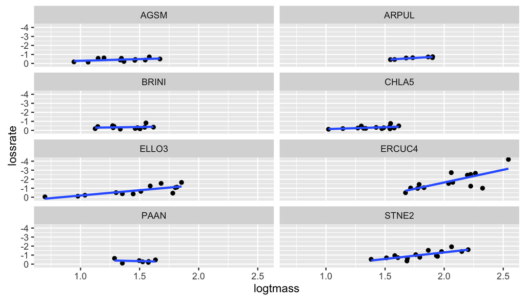

B. Smoldering stage

```r
slossFullMod <- lm(lossrate ~ logtmass*sp.cd + density10*sp.cd +
                     density*sp.cd, data = smog.loss)
slossMaNull <- lm(lossrate ~ density10*sp.cd + density*sp.cd,
                  data = smog.loss)
anova(slossFullMod, slossMaNull)
```

```
## Analysis of Variance Table
##
## Model 1: lossrate ~ logtmass * sp.cd + density10 * sp.cd + density * sp.cd
## Model 2: lossrate ~ density10 * sp.cd + density * sp.cd
##   Res.Df     RSS Df Sum of Sq      F  Pr(>F)
## 1     55 0.87488
## 2     63 1.12783 -8  -0.25296 1.9878 0.06518 .
## ---
## Signif. codes:  0 '***' 0.001 '**' 0.01 '*' 0.05 '.' 0.1 ' ' 1
```

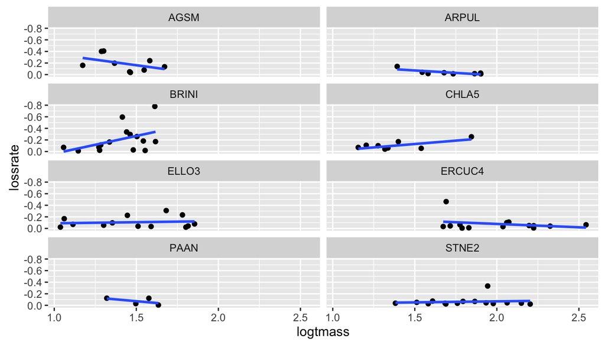

## 3.Does biomass density affect interested flammability measurements?

### 1) biomass density effect on duration

A. >10cm

```r
durFullMod <- lm( dur ~ logtmass*sp.cd + density*sp.cd,
                  data = temp.abovesec)
durDenNull <- lm(dur ~ logtmass*sp.cd, data = temp.abovesec)
anova(durFullMod, durDenNull)
```

```
## Analysis of Variance Table
##
## Model 1: dur ~ logtmass * sp.cd + density * sp.cd
## Model 2: dur ~ logtmass * sp.cd
##   Res.Df     RSS Df Sum of Sq      F Pr(>F)
## 1     85 5827948
## 2     93 5877599 -8    -49650 0.0905 0.9994
```

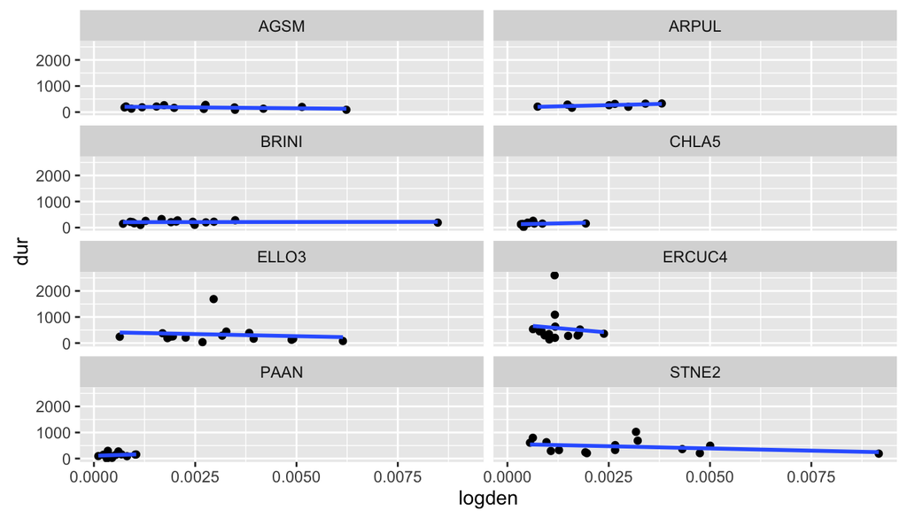

B.<10cm

```r
dur10FullMod <- lm( dur ~ logtmass*sp.cd + density10*sp.cd,
                    data = temp.belowsec)
dur10DenNull <- lm(dur ~ logtmass*sp.cd, data = temp.belowsec)
anova(dur10FullMod, dur10DenNull)
```

```
## Analysis of Variance Table
##
## Model 1: dur ~ logtmass * sp.cd + density10 * sp.cd
## Model 2: dur ~ logtmass * sp.cd
##   Res.Df     RSS Df Sum of Sq      F Pr(>F)
## 1     85 6438256
## 2     93 6722781 -8   -284525 0.4695 0.8744
```

[figure not shown]

**Conclusion** There is no inlfuence of biomass density on duration

### 2) biomass density effect on total degree of temperature(>60)

A. >10cm

```r
degFullMod <- lm(degsec ~ logtmass*sp.cd + density*sp.cd,
                 data = temp.abovesec)
degDenNull <- lm(degsec ~ logtmass*sp.cd, data = temp.abovesec)
anova(degFullMod, degDenNull)
```

```
## Analysis of Variance Table
##
## Model 1: degsec ~ logtmass * sp.cd + density * sp.cd
## Model 2: degsec ~ logtmass * sp.cd
##   Res.Df        RSS Df  Sum of Sq      F Pr(>F)
## 1     85 5.6001e+10
## 2     93 5.7829e+10 -8 -1.828e+09 0.3468 0.9448
```

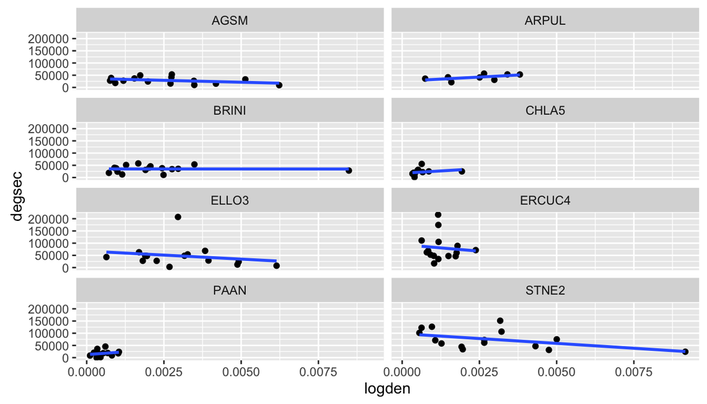

B.<10cm

```r
deg10FullMod <- lm(degsec ~ logtmass*sp.cd + density10*sp.cd,
                   data = temp.belowsec)
deg10DenNull <- lm(degsec ~ logtmass*sp.cd, data = temp.belowsec)
anova(deg10FullMod, deg10DenNull)
```

```
## Analysis of Variance Table
##
## Model 1: degsec ~ logtmass * sp.cd + density10 * sp.cd
## Model 2: degsec ~ logtmass * sp.cd
##   Res.Df        RSS Df   Sum of Sq      F Pr(>F)
## 1     85 1.1828e+11
## 2     93 1.2506e+11 -8 -6778490283 0.6089  0.768
```

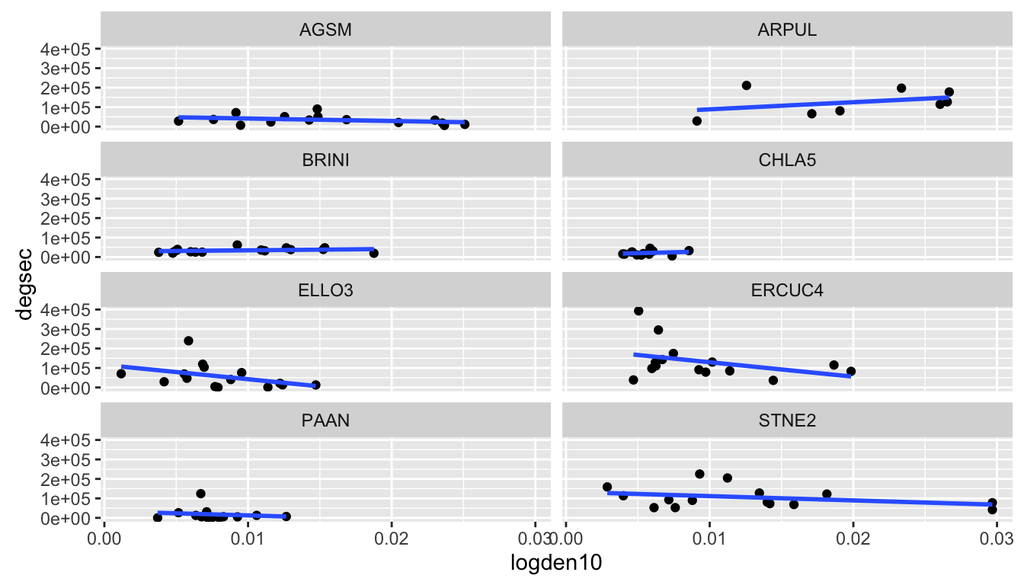

**Conclusion** There is no significant biomass density effect on total degree of temperature(>60) produced

### 3) biomass density effect on maximum flame height

A. biomass density at >10cm

```r
flamhFullMod <- lm(max.fh ~ logtmass*sp.cd + density10*sp.cd +
                     density*sp.cd + height*sp.cd, data = flam.height)
flamhDenNull <- lm(max.fh ~ logtmass*sp.cd + density10*sp.cd +
                    height*sp.cd, data = flam.height)
anova(flamhFullMod, flamhDenNull)
```

```
## Analysis of Variance Table
##
## Model 1: max.fh ~ logtmass * sp.cd + density10 * sp.cd + density * sp.cd +
##     height * sp.cd
## Model 2: max.fh ~ logtmass * sp.cd + density10 * sp.cd + height * sp.cd
##   Res.Df   RSS Df Sum of Sq      F Pr(>F)
## 1     84 33190
## 2     92 34189 -8   -999.63 0.3162 0.9579
```

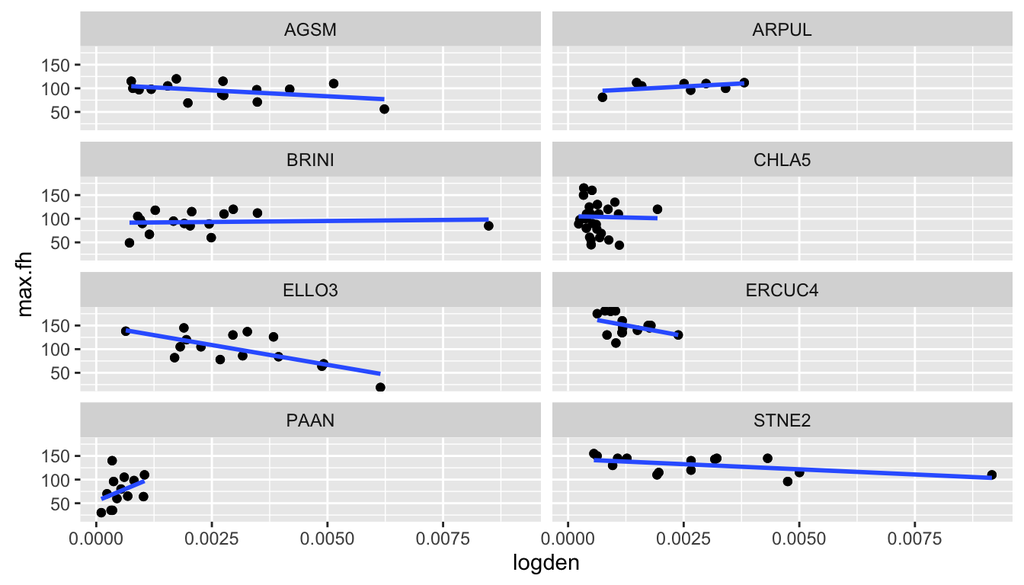

B. biomass density at <10cm

```r
flamhFullMod <- lm(max.fh ~ logtmass*sp.cd + density10*sp.cd +
                     density*sp.cd + height*sp.cd, data = flam.height)
flamhDen10Null <- lm(max.fh ~ logtmass*sp.cd + density*sp.cd +
                    height*sp.cd, data = flam.height)
anova(flamhFullMod, flamhDen10Null)
```

```
## Analysis of Variance Table
##
## Model 1: max.fh ~ logtmass * sp.cd + density10 * sp.cd + density * sp.cd +
##     height * sp.cd
## Model 2: max.fh ~ logtmass * sp.cd + density * sp.cd + height * sp.cd
##   Res.Df   RSS Df Sum of Sq      F Pr(>F)
## 1     84 33190
## 2     92 36481 -8   -3291.7 1.0414 0.4121
```

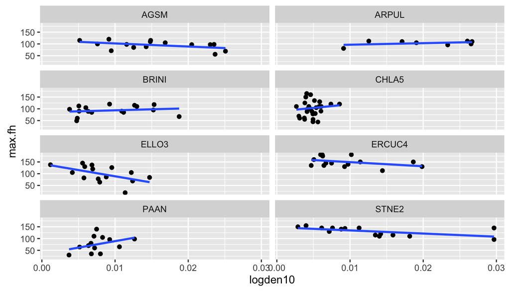

**Conclusion** There is no significant biomass density influence on maximum flame height

### 4) biomass density effect on biomass loss rate at two stages

A. Flaming stage density at >10cm

```r
flossFullMod <- lm(lossrate ~ logtmass*sp.cd + density10*sp.cd +
                     density*sp.cd, data = flam.loss)
flossDenNull <- lm(lossrate ~ logtmass*sp.cd + density10*sp.cd,
                  data = flam.loss)
anova(flossFullMod, flossDenNull)
```

```
## Analysis of Variance Table
##
## Model 1: lossrate ~ logtmass * sp.cd + density10 * sp.cd + density * sp.cd
## Model 2: lossrate ~ logtmass * sp.cd + density10 * sp.cd
##   Res.Df    RSS Df Sum of Sq      F Pr(>F)
## 1     63 8.4832
## 2     71 9.1318 -8  -0.64864 0.6021 0.7726
```

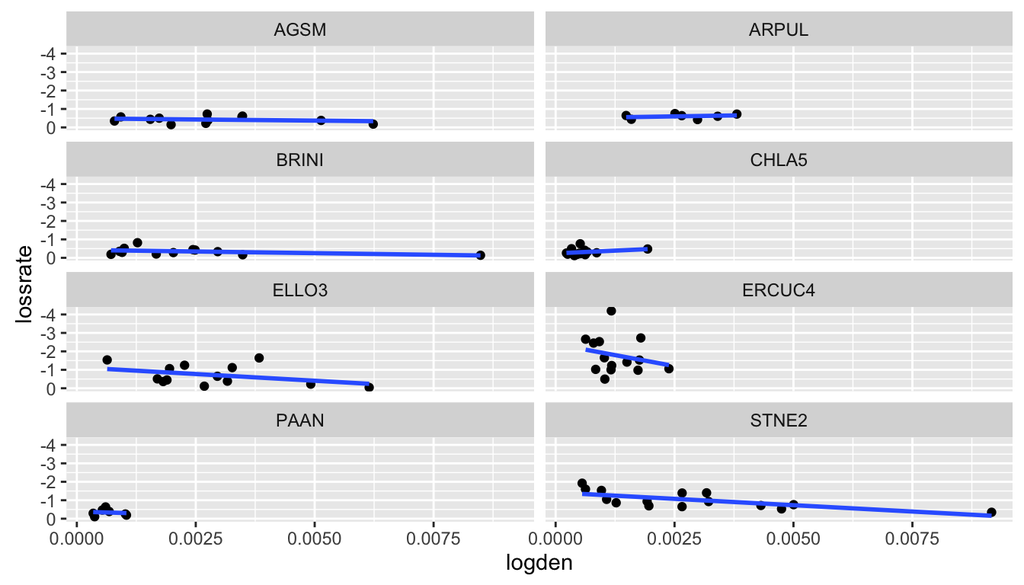

density at <10cm

```r
flossFullMod <- lm(lossrate ~ logtmass*sp.cd + density10*sp.cd +
                     density*sp.cd, data = flam.loss)
flossDen10Null <- lm(lossrate ~ logtmass*sp.cd + density*sp.cd,
                  data = flam.loss)
anova(flossFullMod, flossDen10Null)
```

```
## Analysis of Variance Table
##
## Model 1: lossrate ~ logtmass * sp.cd + density10 * sp.cd + density * sp.cd
## Model 2: lossrate ~ logtmass * sp.cd + density * sp.cd
##   Res.Df    RSS Df Sum of Sq      F Pr(>F)
## 1     63 8.4832
## 2     71 8.8902 -8  -0.40701 0.3778 0.9285
```

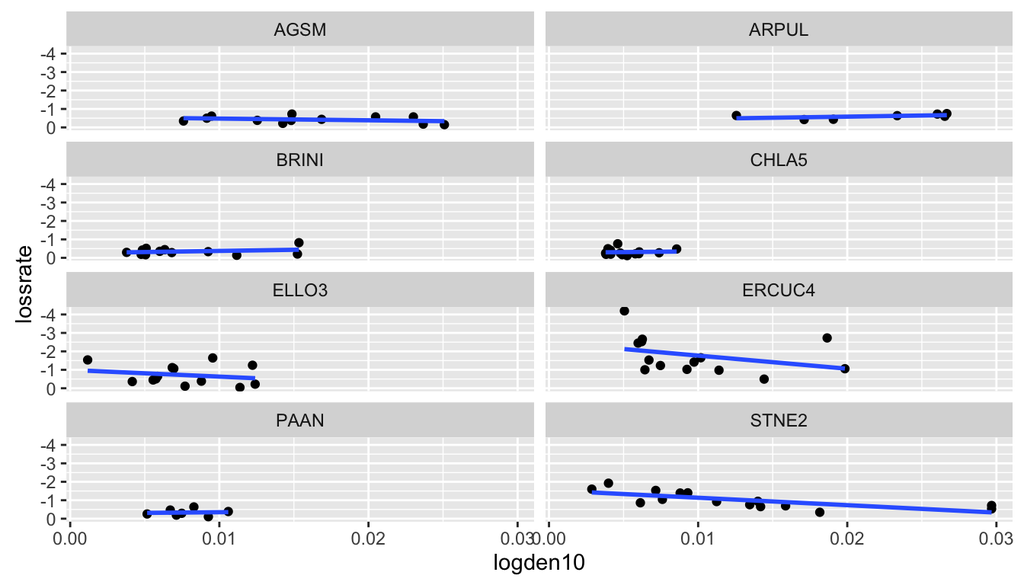

B. Smoldering stage density at >10cm

```r
slossFullMod <- lm(lossrate ~ logtmass*sp.cd + density10*sp.cd +
                     density*sp.cd, data = smog.loss)
slossDenNull <- lm(lossrate ~ density10*sp.cd + logtmass*sp.cd,
                  data = smog.loss)
anova(slossFullMod, slossDenNull)
```

```
## Analysis of Variance Table
##
## Model 1: lossrate ~ logtmass * sp.cd + density10 * sp.cd + density * sp.cd
## Model 2: lossrate ~ density10 * sp.cd + logtmass * sp.cd
##   Res.Df     RSS Df Sum of Sq      F Pr(>F)
## 1     55 0.87488
## 2     63 0.89935 -8 -0.024477 0.1924 0.9909
```

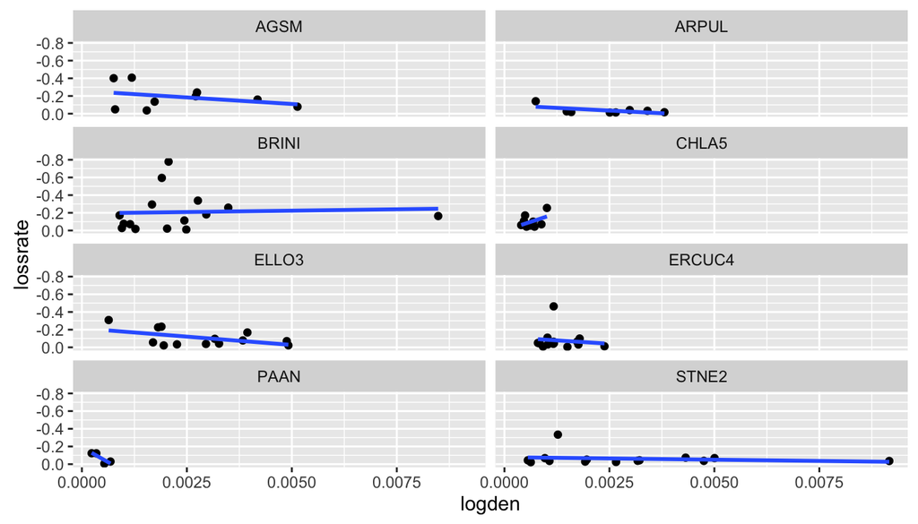

density at <10cm

```r
slossFullMod <- lm(lossrate ~ logtmass*sp.cd + density10*sp.cd +
                     density*sp.cd, data = smog.loss)
slossDen10Null <- lm(lossrate ~ density*sp.cd + logtmass*sp.cd,
                  data = smog.loss)
anova(slossFullMod, slossDen10Null)
```

```
## Analysis of Variance Table
##
## Model 1: lossrate ~ logtmass * sp.cd + density10 * sp.cd + density * sp.cd
## Model 2: lossrate ~ density * sp.cd + logtmass * sp.cd
##   Res.Df     RSS Df Sum of Sq   F Pr(>F)
## 1     55 0.87488
## 2     63 0.98941 -8  -0.11453 0.9  0.523
```

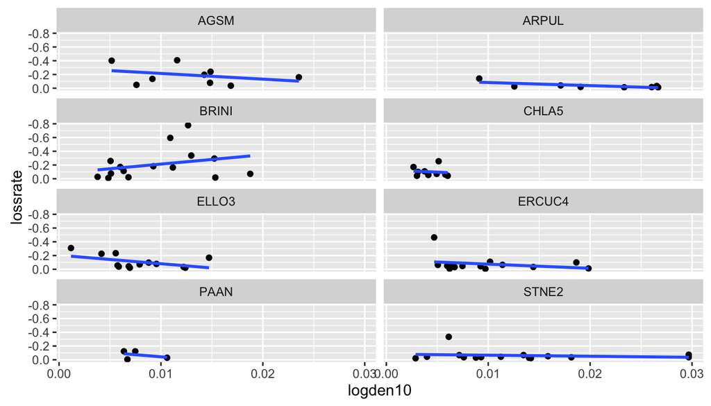

**Conclusion** Thers is no biomss density effect on biomass loss rate Therefore, seems biomass density has no influence on flammability at all…

### 5) if plant height affects maximum flame height

```r
flamhFullMod <- lm(max.fh ~ logtmass*sp.cd + density10*sp.cd +
                     density*sp.cd + height*sp.cd, data = flam.height)
flamhHeiNull <- lm(max.fh ~ logtmass*sp.cd + density*sp.cd +
                     density10*sp.cd, data = flam.height)
anova(flamhFullMod, flamhHeiNull)
```

```
## Analysis of Variance Table
##
## Model 1: max.fh ~ logtmass * sp.cd + density10 * sp.cd + density * sp.cd +
##     height * sp.cd
## Model 2: max.fh ~ logtmass * sp.cd + density * sp.cd + density10 * sp.cd
##   Res.Df   RSS Df Sum of Sq      F Pr(>F)
## 1     84 33190
## 2     92 37364 -8   -4174.9 1.3208 0.2445
```

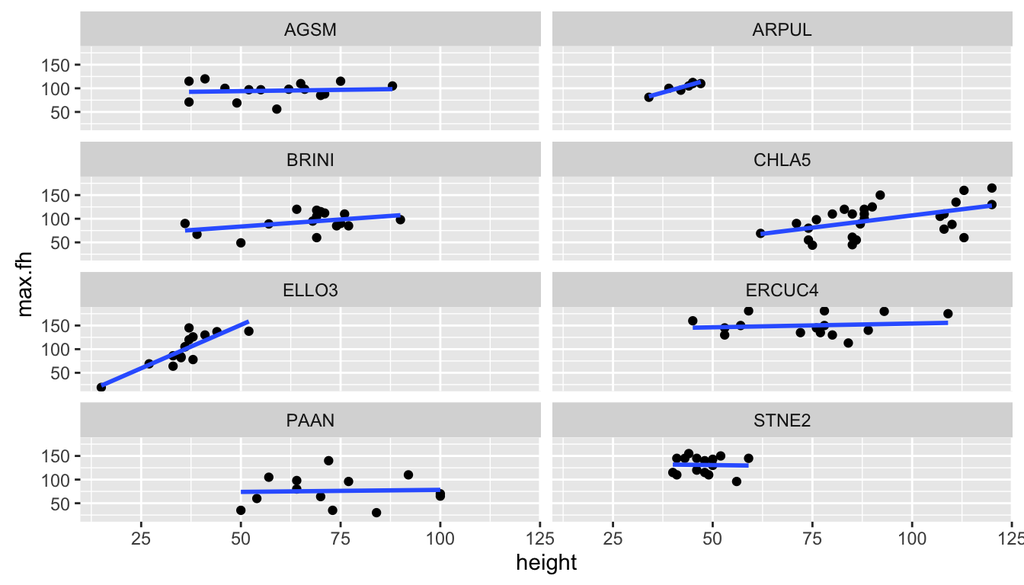

**Conclusion** Plant height does not have effect on maximum flame height.